# Air_sea_CO2_flux_DE CARLO

Mégane

2023-04-17

# **Air–Sea CO<sub>2</sub> Flux – Article DE CARLO**

*period : 2007-2022 complete*

Data used :

- pCO<sub>2</sub> water (µatm)  
  Frequency : Weekly
- pCO<sub>2</sub> air (µpm)  
  Frequency : Hourly
- wind speed 10m (m/s)  
  Frequency : Hourly

## Importation data carbo chemistry - pCO<sub>2</sub> water (Point B SOMLIT)

```
##     datetime             salinity      temperature          ta
##  Min.   :2007-01-09   Min.   :35.39   Min.   :12.51   Min.   :2498
##  1st Qu.:2010-12-19   1st Qu.:37.80   1st Qu.:14.61   1st Qu.:2548
##  Median :2014-11-19   Median :38.02   Median :18.05   Median :2556
##  Mean   :2014-11-16   Mean   :37.94   Mean   :18.83   Mean   :2556
##  3rd Qu.:2018-09-05   3rd Qu.:38.15   3rd Qu.:22.71   3rd Qu.:2565
##  Max.   :2022-12-20   Max.   :38.41   Max.   :28.42   Max.   :2589
##                       NA's   :74      NA's   :79      NA's   :124
##       dic            NO2              NO3              Chla
##  Min.   :2190   Min.   :0.0000   Min.   :0.0000   Min.   :0.0170
##  1st Qu.:2233   1st Qu.:0.0200   1st Qu.:0.1690   1st Qu.:0.1827
##  Median :2248   Median :0.0500   Median :0.3150   Median :0.2540
##  Mean   :2249   Mean   :0.1016   Mean   :0.4592   Mean   :0.3079
##  3rd Qu.:2263   3rd Qu.:0.1585   3rd Qu.:0.5450   3rd Qu.:0.3890
##  Max.   :2313   Max.   :0.7310   Max.   :4.6070   Max.   :1.4600
##  NA's   :130    NA's   :277      NA's   :255      NA's   :152
##     pH_calc          pCO2_w          Year            Year.Month
##  Min.   :7.915   Min.   :309.8   Length:820         Length:820
##  1st Qu.:8.036   1st Qu.:360.3   Class :character   Class :character
##  Median :8.087   Median :391.1   Mode  :character   Mode  :character
##  Mean   :8.074   Mean   :408.9
##  3rd Qu.:8.117   3rd Qu.:446.0
##  Max.   :8.173   Max.   :618.6
##  NA's   :140     NA's   :140
```

### **Nombre de mesures SOMLIT par mois**

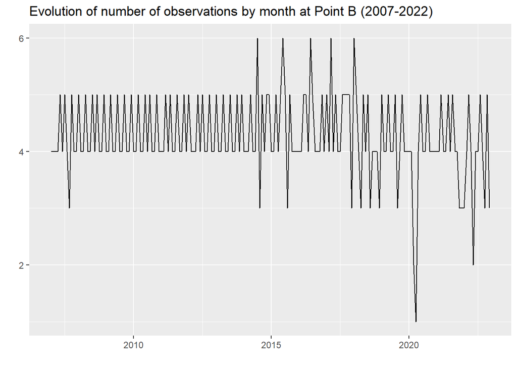

### Visualisation and linear interpolation of salinity and temperature data (Point B - 2007-2022)

→ *possibilité de rajouter des données jusqu’en décembre 2022 pour salinité + température (voire script “SOMLIT_2022”)*

##### Salinity (74 NA) & Temperature (79 NA) :

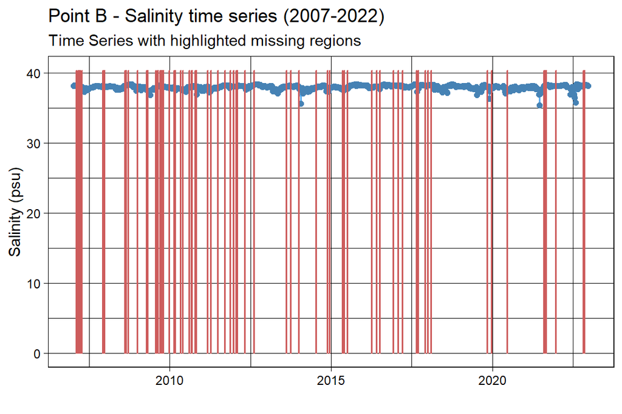

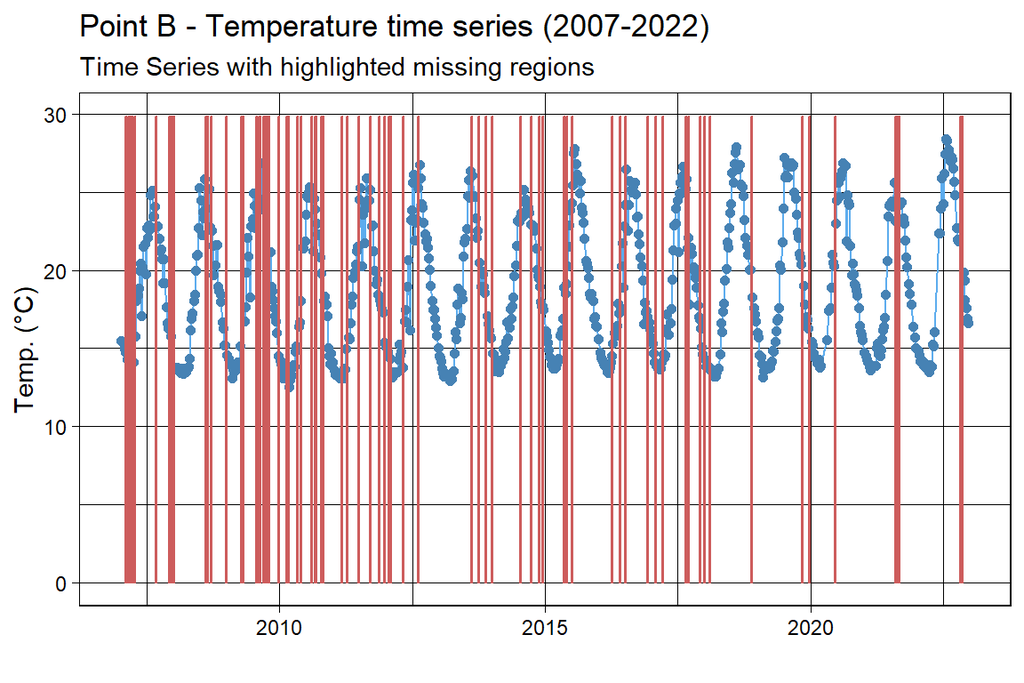

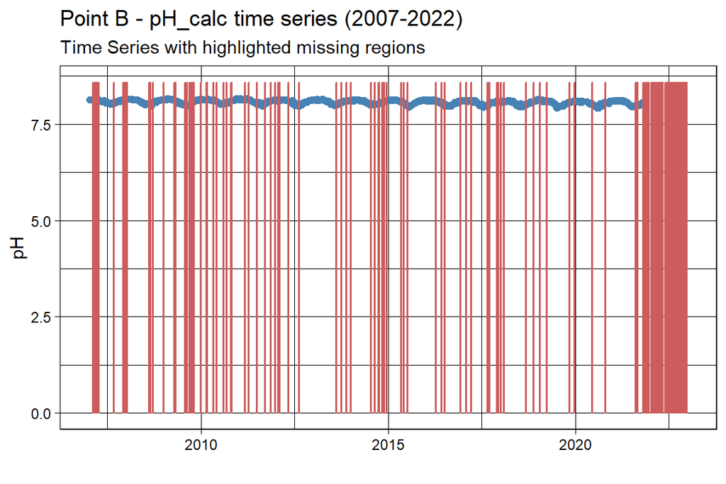

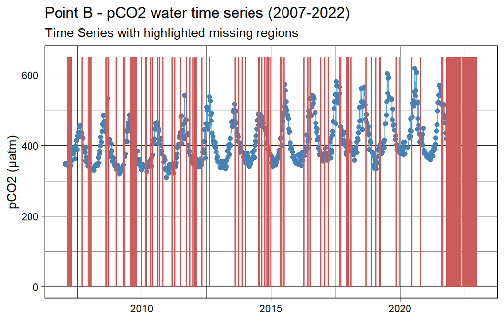

## Importation data pCO<sub>2</sub> atmosphere (ICOS)

→ 5 sites  
→ Frequency : hourly  
→ Selection of data taken at 09:00 AM

```
##     datetime                      CO2_LAMP         CO2_MC          CO2_PR
##  Min.   :2006-10-01 00:00:00   Min.   :375.8   Min.   :377.4   Min.   :376.0
##  1st Qu.:2010-08-08 06:00:00   1st Qu.:393.0   1st Qu.:396.6   1st Qu.:392.6
##  Median :2014-06-15 12:00:00   Median :402.0   Median :403.8   Median :401.4
##  Mean   :2014-06-15 12:25:31   Mean   :401.6   Mean   :403.9   Mean   :401.3
##  3rd Qu.:2018-04-22 18:00:00   3rd Qu.:410.0   3rd Qu.:411.0   3rd Qu.:410.2
##  Max.   :2022-02-28 00:00:00   Max.   :425.2   Max.   :439.4   Max.   :429.9
##                                NA's   :1805    NA's   :2356    NA's   :1354
##    CO2_CORSE         CO2_HP
##  Min.   :385.7   Min.   :384.1
##  1st Qu.:402.0   1st Qu.:406.1
##  Median :408.4   Median :411.9
##  Mean   :408.3   Mean   :412.1
##  3rd Qu.:415.1   3rd Qu.:418.4
##  Max.   :433.7   Max.   :450.8
##  NA's   :3398    NA's   :3086
```

## Visualisation 5 sites atmospheric pCO<sub>2</sub>

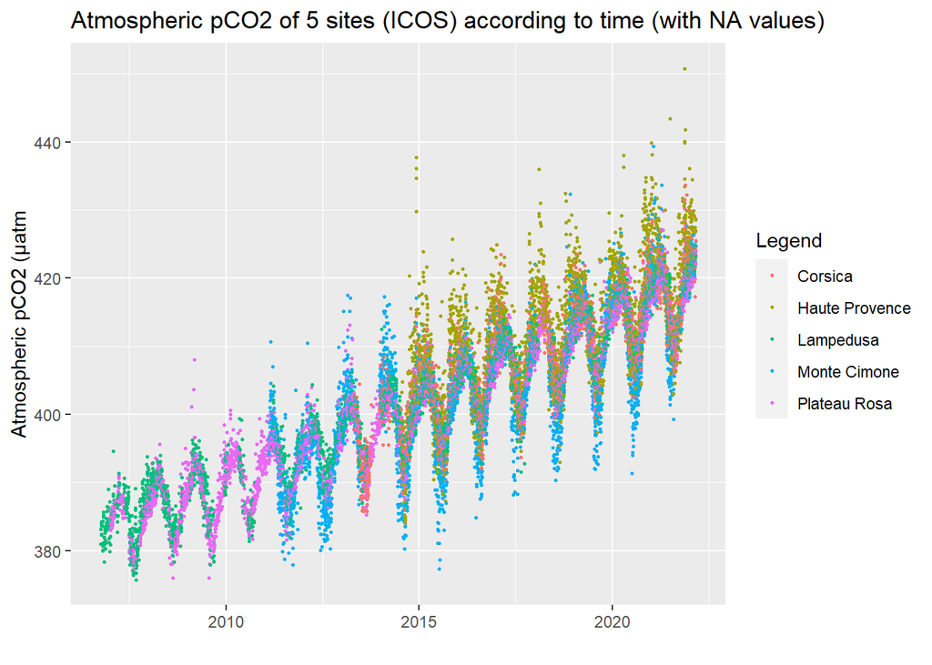

## Visualisation 5 sites atmospheric pCO<sub>2</sub> NA values

#### 1 : **Lampedusa site (2006-2022)**

Number of NA : 1805

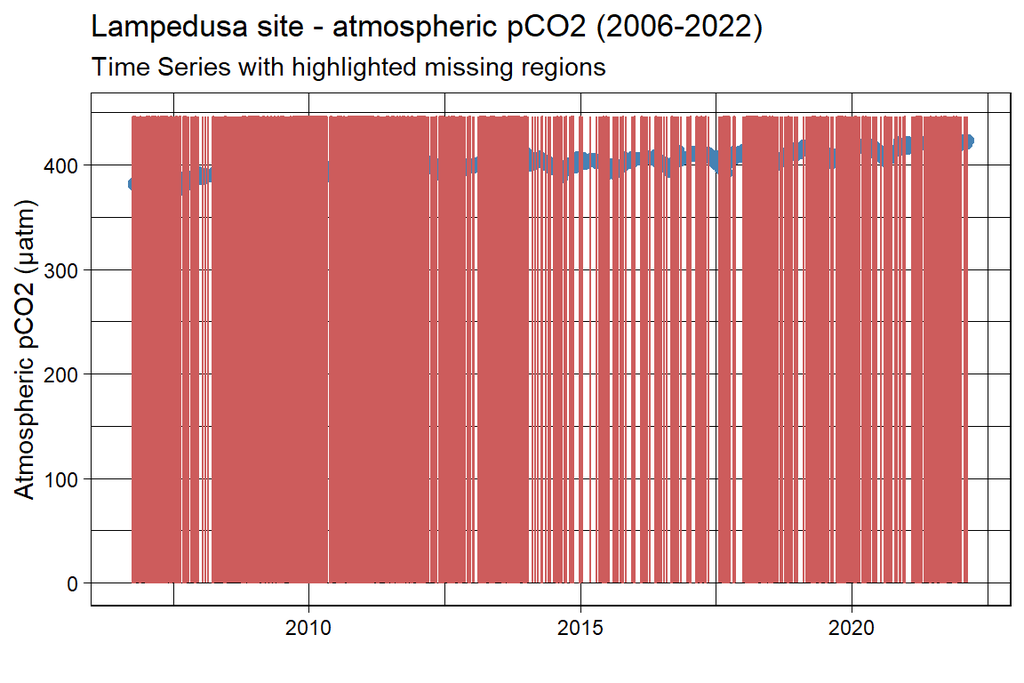

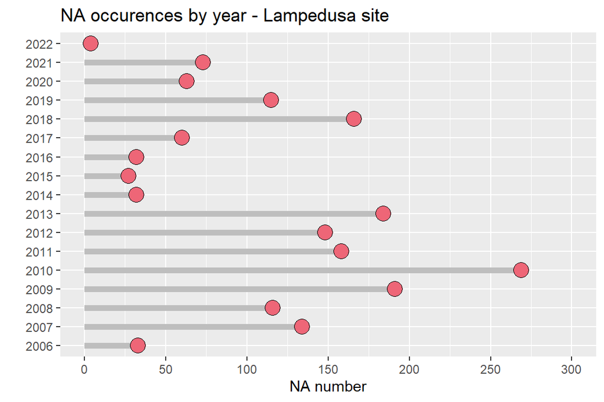

#### 2 : **Plateau Rosa site (2007-2022)**

Number of NA : 1354

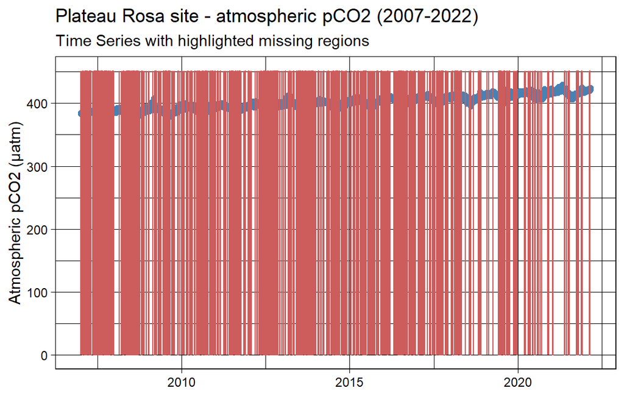

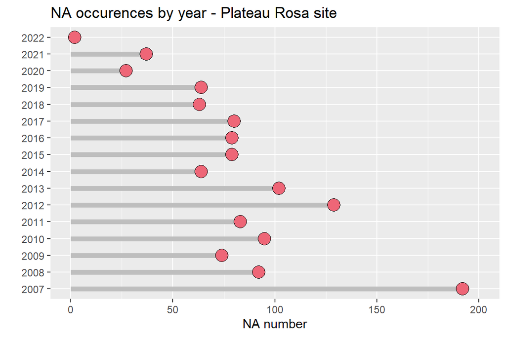

#### 3 : **Monte Cimone site (2011-2022)**

Number of NA : 2356

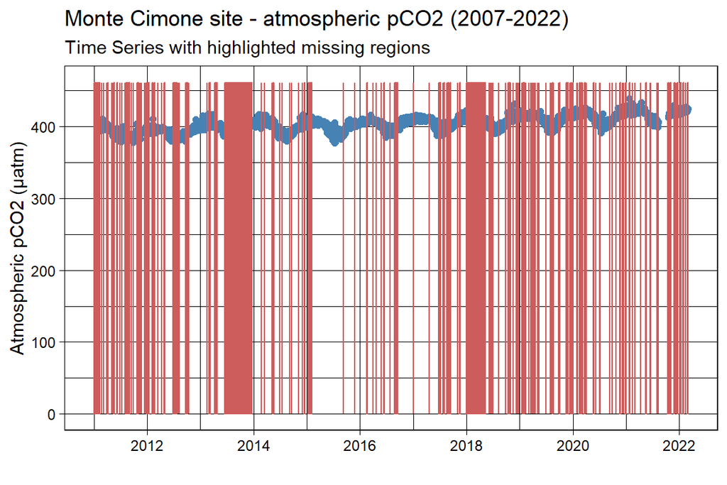

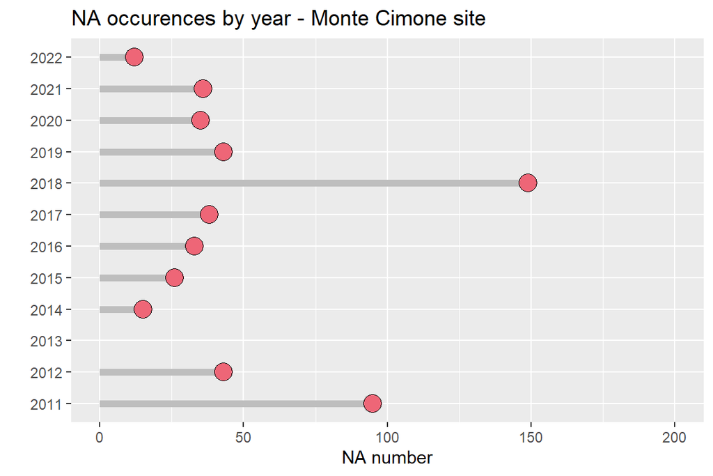

#### 4 : **Corsica site (2013-2022)**

Number of NA : 3398

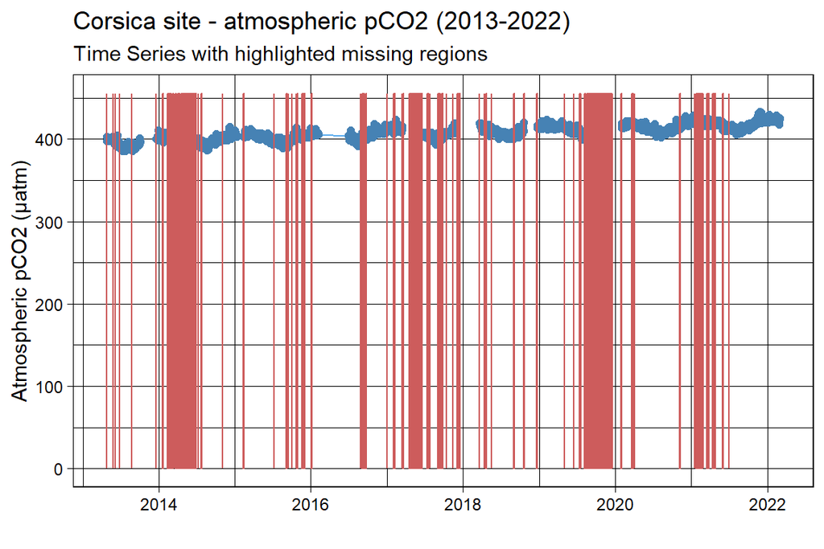

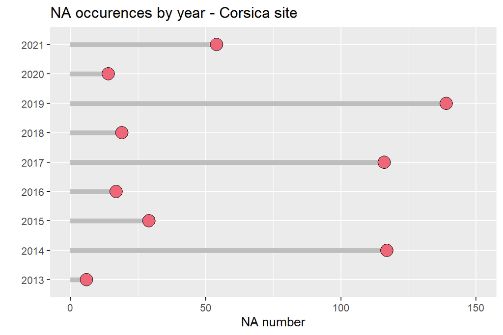

#### 5 : **Haute-Provence observatory site (2014-2022)**

Number of NA : 3086

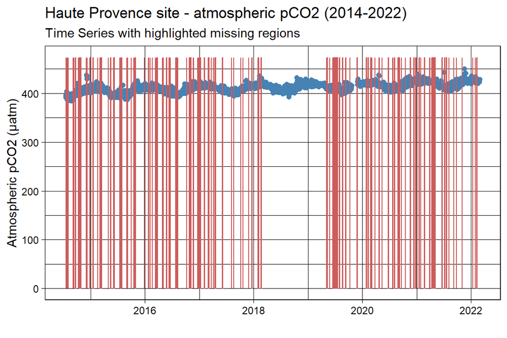

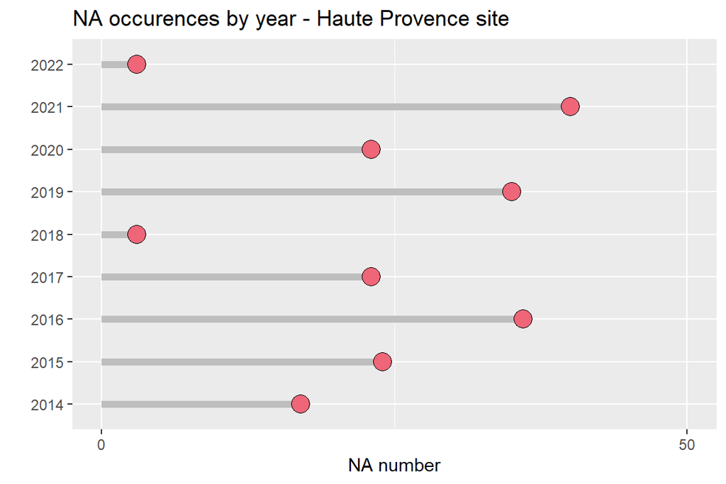

## Cross interpolations of 5 sites atmospheric pCO<sub>2</sub> data

### Cross interpolation between Corsica and Haute Provence datasets :

```
##    Min. 1st Qu.  Median    Mean 3rd Qu.    Max.    NA's
##   385.7   402.4   408.8   408.7   415.3   433.9     189
```

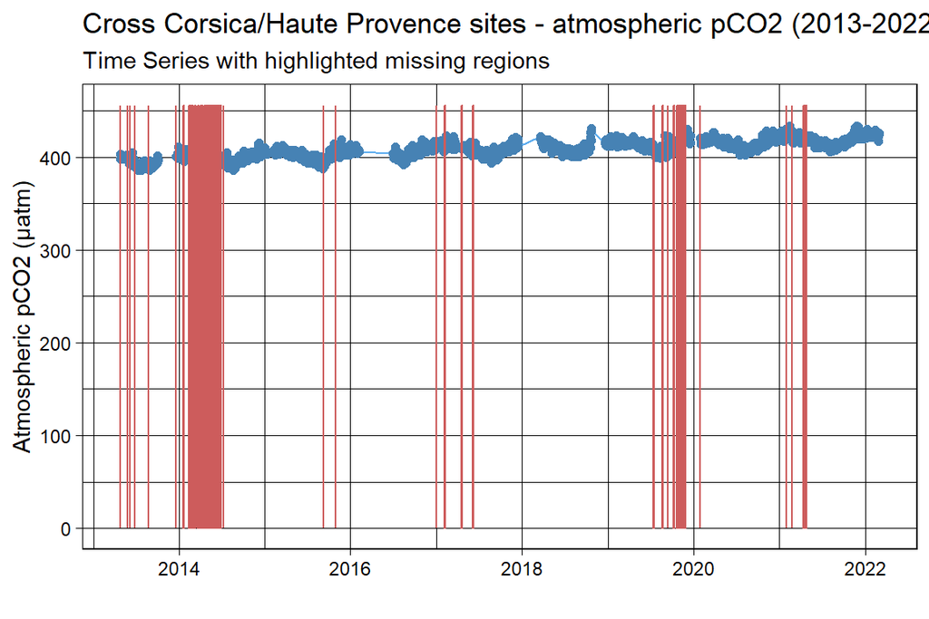

### Cross interpolation between Corsica/HP and Monte Cimone datasets :

```
##    Min. 1st Qu.  Median    Mean 3rd Qu.    Max.    NA's
##   377.4   396.4   403.9   404.1   411.7   439.4     381
```

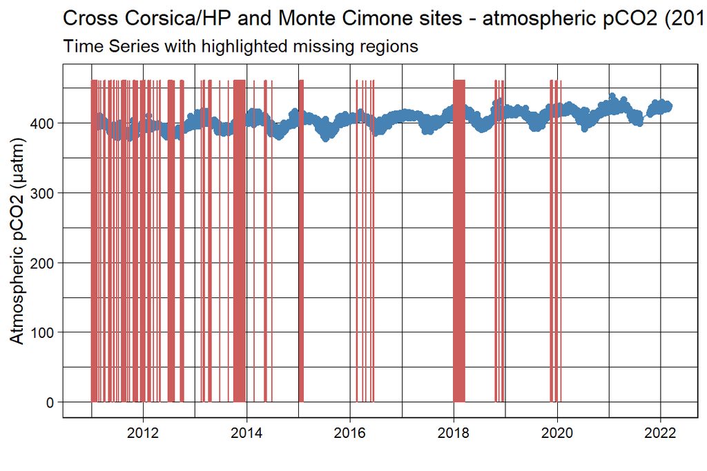

### Cross interpolation between Corsica/HP/Monte Cimone and Plateau Rosa datasets :

```
##    Min. 1st Qu.  Median    Mean 3rd Qu.    Max.    NA's
##   376.0   392.4   401.1   401.0   409.7   429.9     573
```

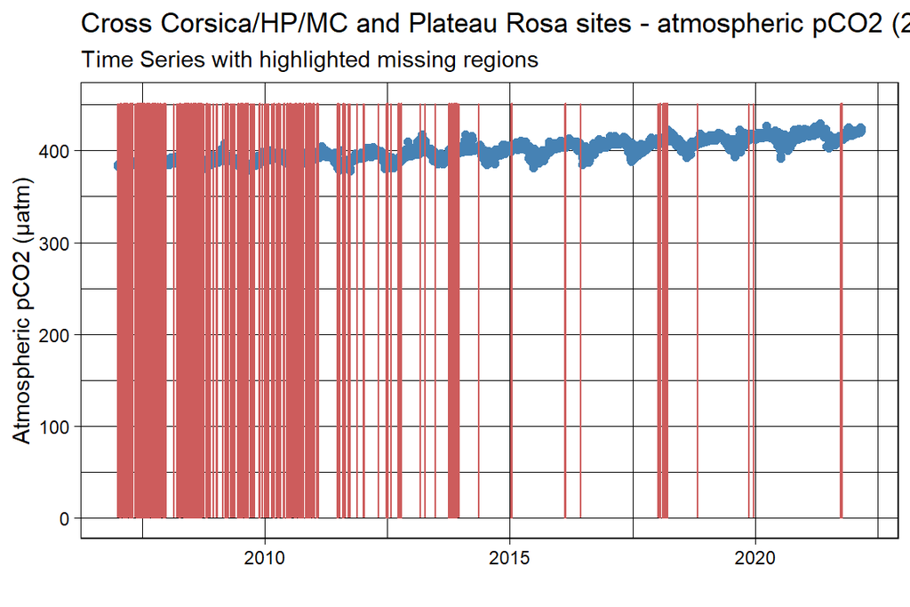

### Cross interpolation between Corsica/HP/MC/PR and Lampedusa datasets :

```
##    Min. 1st Qu.  Median    Mean 3rd Qu.    Max.    NA's
##   375.8   391.7   400.3   400.6   409.5   426.4     309
```

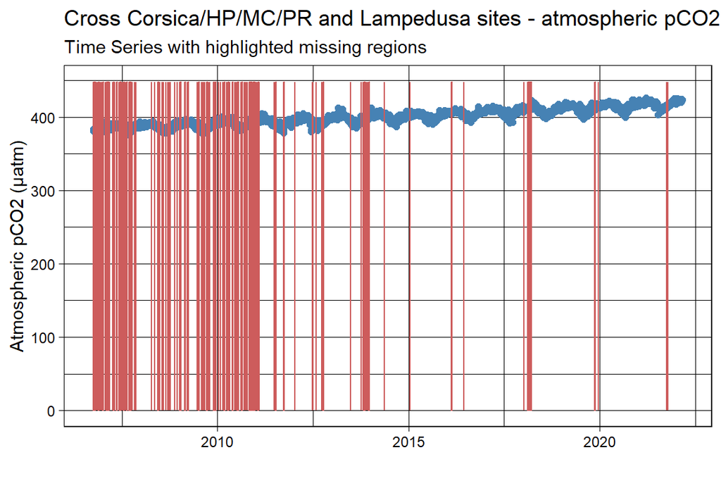

## Visualisation of atmospheric pCO<sub>2</sub> cross-interpolated (5 sites) + missing values

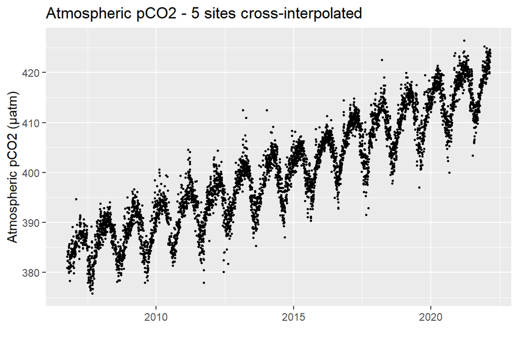

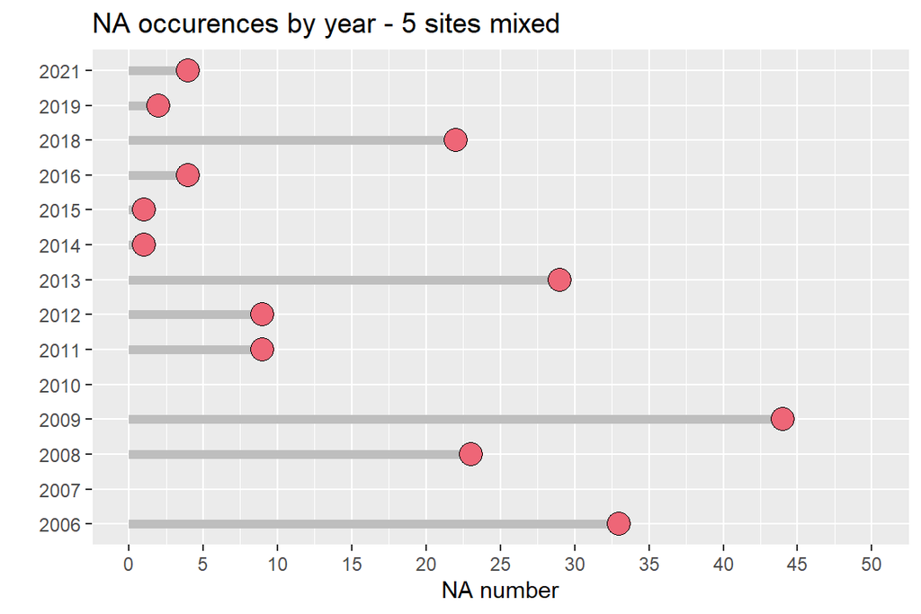

## Visualisation of imputed values of atmospheric pCO<sub>2</sub> data (linear interpolation)

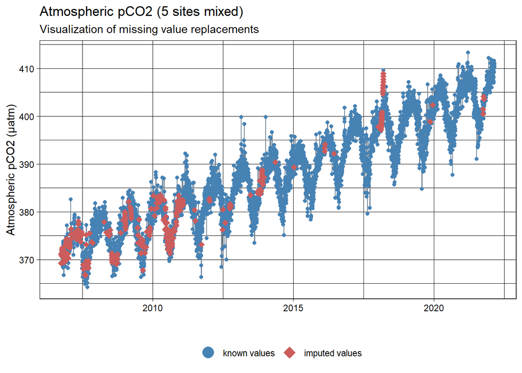

## Importation data wind speed 10m (m/s) - 2007-2022

Frequency : Hourly

```
##     datetime                   wind_speed_ms
##  Min.   :2007-01-01 00:00:00   Min.   : 0.000
##  1st Qu.:2011-04-13 04:00:00   1st Qu.: 3.600
##  Median :2014-11-24 12:00:00   Median : 6.990
##  Mean   :2014-10-06 04:06:35   Mean   : 9.046
##  3rd Qu.:2018-05-02 19:00:00   3rd Qu.:12.440
##  Max.   :2022-01-30 23:00:00   Max.   :98.000
##                                NA's   :9547
```

→ Selection of Wind speed data only at 09:00 AM (m/s)

```
##    Min. 1st Qu.  Median    Mean 3rd Qu.    Max.    NA's
##   0.000   3.490   7.000   9.146  13.000  40.430     396
```

## Visualisation data wind speed NA values

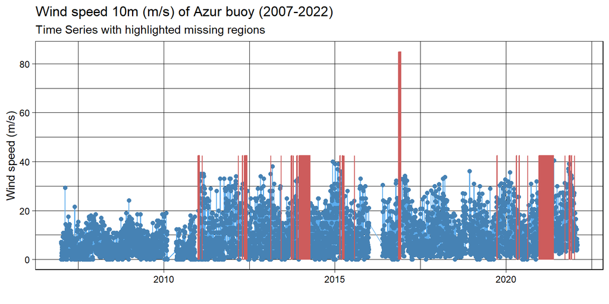

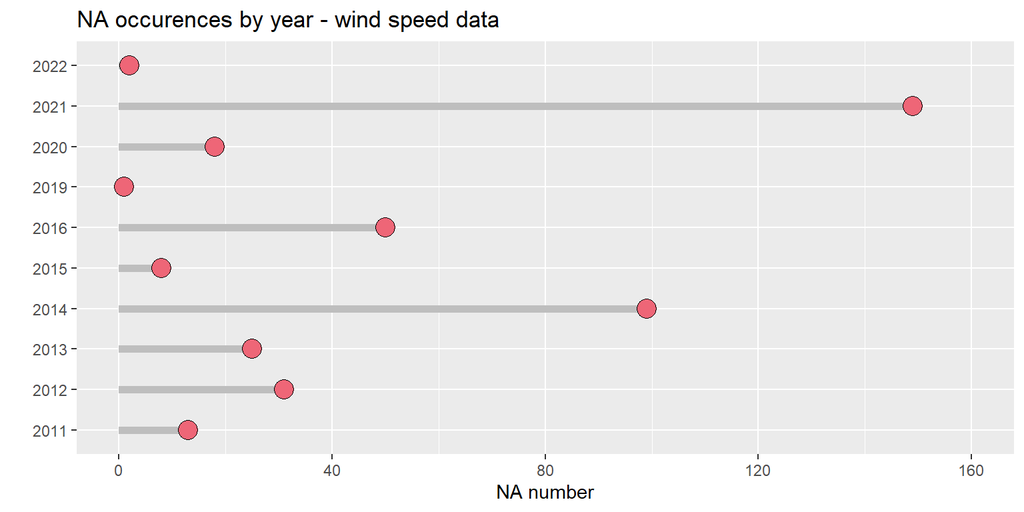

## Visualisation of imputed values - wind speed data (linear interpolation)

→ *pas la bonne methode car trop de consecutive NA (ex : years 2014 & 2021)*

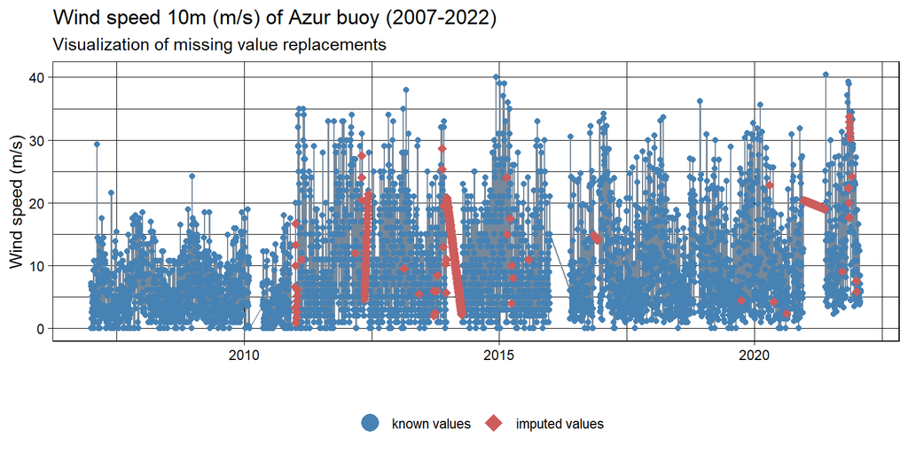

## **Merge of 3 tables :**

- SOMLIT_carbo_chemistry_surf (pCO<sub>2</sub> water in µatm) → frequency = weekly
- pCO2_CORSE_HP_MC_PR_LAMP (pCO<sub>2</sub> air in µatm) → frequency = daily
- Azur_wind_RAW (wind speed in m/S) → frequency = daily

```
##    datetime            salinity      temperature          ta
##  Length:850         Min.   :35.39   Min.   :12.51   Min.   :2498
##  Class :character   1st Qu.:37.81   1st Qu.:14.76   1st Qu.:2549
##  Mode  :character   Median :38.03   Median :18.26   Median :2556
##                     Mean   :37.95   Mean   :18.94   Mean   :2556
##                     3rd Qu.:38.16   3rd Qu.:22.85   3rd Qu.:2565
##                     Max.   :38.41   Max.   :28.42   Max.   :2589
##                                                     NA's   :126
##       dic            NO2               NO3              Chla
##  Min.   :2190   Min.   :0.00000   Min.   :0.0000   Min.   :0.0170
##  1st Qu.:2234   1st Qu.:0.02000   1st Qu.:0.1755   1st Qu.:0.1828
##  Median :2248   Median :0.05000   Median :0.3140   Median :0.2540
##  Mean   :2249   Mean   :0.09798   Mean   :0.4512   Mean   :0.3059
##  3rd Qu.:2263   3rd Qu.:0.14300   3rd Qu.:0.5280   3rd Qu.:0.3800
##  Max.   :2313   Max.   :0.73100   Max.   :4.6070   Max.   :1.4600
##  NA's   :132    NA's   :277       NA's   :255      NA's   :152
##     pH_calc          pCO2_w          Year            Year.Month
##  Min.   :7.915   Min.   :309.8   Length:850         Length:850
##  1st Qu.:8.037   1st Qu.:364.0   Class :character   Class :character
##  Median :8.077   Median :399.7   Mode  :character   Mode  :character
##  Mean   :8.071   Mean   :411.1
##  3rd Qu.:8.113   3rd Qu.:445.9
##  Max.   :8.173   Max.   :618.6
##
##    wind_imput       pCO2_imput
##  Min.   : 0.000   Min.   :366.3
##  1st Qu.: 3.600   1st Qu.:380.0
##  Median : 6.990   Median :387.7
##  Mean   : 9.229   Mean   :388.0
##  3rd Qu.:13.875   3rd Qu.:395.5
##  Max.   :40.430   Max.   :411.2
##  NA's   :112      NA's   :39
```

## Atmospheric and water pCO<sub>2</sub> (µatm) according to time (2007-2022)

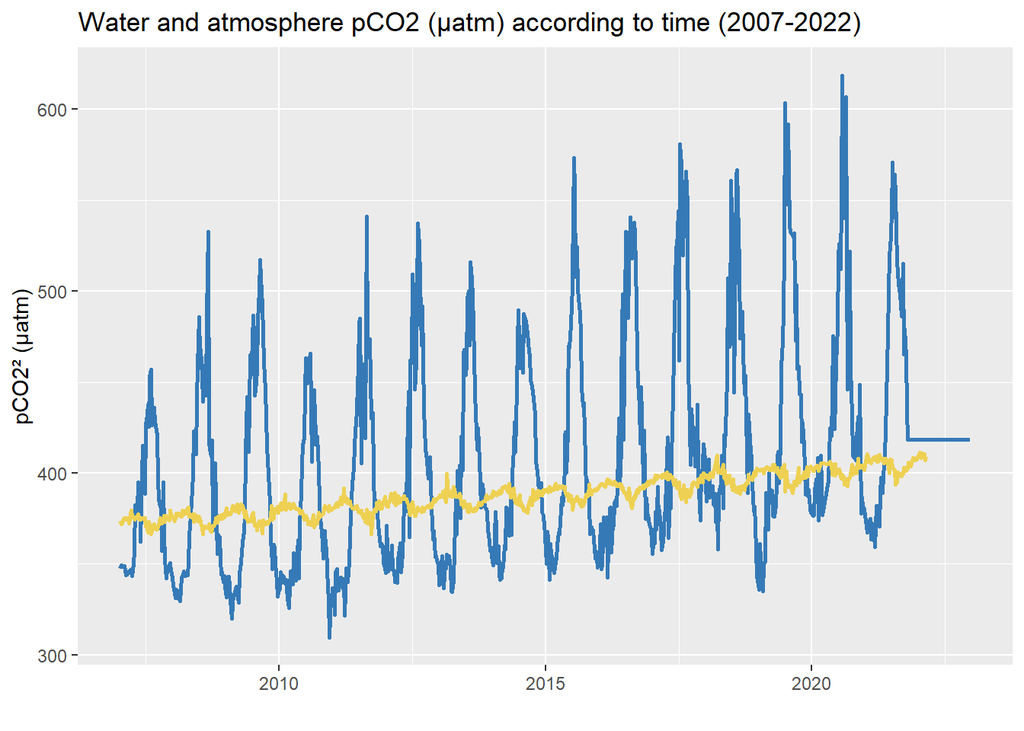

### Calcul de T-normalized (=NpCO<sub>2</sub> seawater)

→ Corresponding to non-temperature effects on pCO<sub>2</sub> water variations

Formula : NpCO<sub>2</sub> = pCO<sub>2</sub>w obs * e(0.0423 * Tmean-Tobs)

```r
#formula : pCO2(N) = pCO2w obs * e(0.0423*Tmean-Tobs) = NpCO2 de Kapsenber

#calcul de Tmean :
Tmean <- mean(DATA$temperature, na.rm=T) #18.88

#calcul de NpCO2
DATA <- DATA %>%
  dplyr::mutate(NpCO2 = pCO2_w * exp(0.0423*(Tmean-temperature)))
```

### pCO<sub>2</sub> at Point B : 2007-2021

(Figure 5.a DE CARLO)

*(rajouter legende plot)*

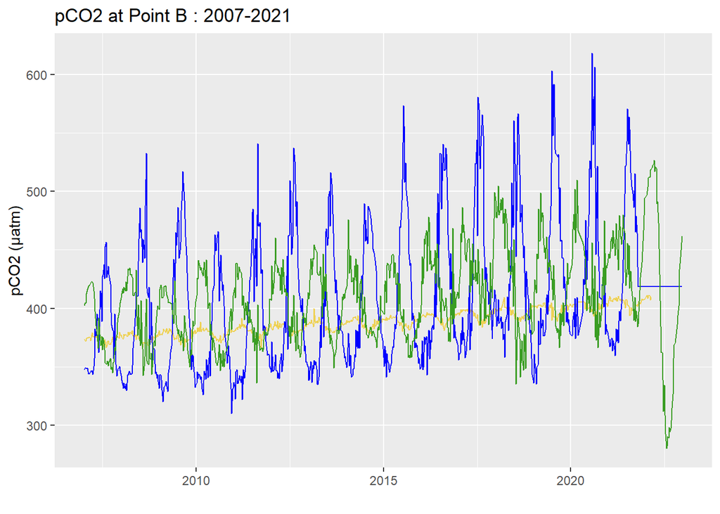

```r
##Figure 5.a DE CARLO :

DATA %>%
  ggplot() +
  ggtitle("pCO2 at Point B : 2007-2021") +
  geom_line(aes(x=datetime, y=pCO2_imput), col='#EED153') +
  geom_line(aes(x=datetime, y=pCO2_w), col='blue') +
  geom_line(aes(x=datetime, y=NpCO2), col='#3A9D23') +
  scale_x_datetime(name="") +
  scale_y_continuous(name="pCO2 (µatm)")
```

### Annual cycle of pCO<sub>2</sub> (2007-2021)

(Figure 5.b DE CARLO)

*Remarque :* augmentation globale des valeurs de pCO<sub>2</sub>(water) au fil des années

*(rajouter legende plot)*

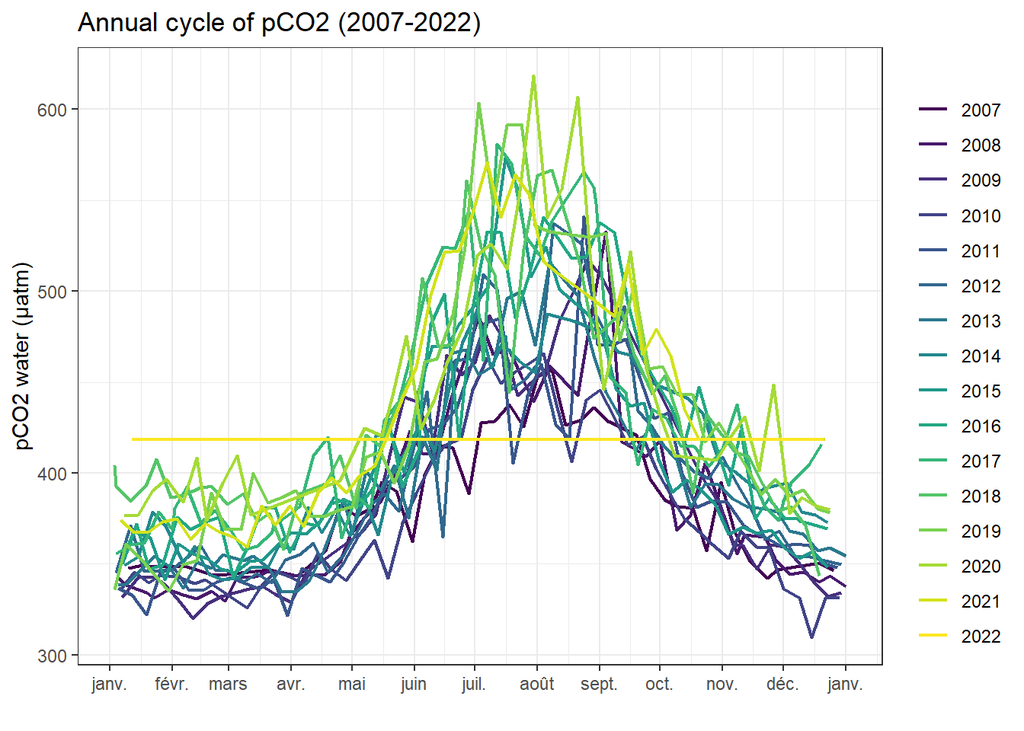

### Calcul de TpCO<sub>2</sub> seawater

→ Corresponding to temperature effects on pCO<sub>2</sub> water variations

Formula : TpCO<sub>2</sub> = pCO<sub>2</sub>mean * exp[0.0423(Tobs - Tmean)]

```r
#the effects of only temperature
#calcul de TpCO2 at Tobs
#formula : TpCO2 = pCO2mean * exp[0.0423(Tobs - Tmean)]

#calcul de pCO2mean :
pCO2mean <- mean(DATA$pCO2_w, na.rm=T) #410.90

#calcul de TpCO2 :
DATA <- DATA %>%
  dplyr::mutate(TpCO2 = pCO2mean * exp(0.0423*(temperature-Tmean)))

##
```

#### Visualisation of TpCO<sub>2</sub> according to time (2007-2022)

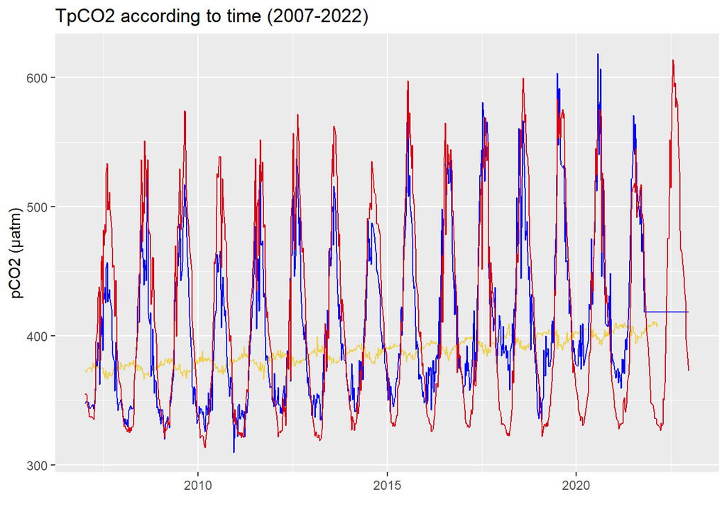

```r
DATA %>%
  ggplot() +
  ggtitle("TpCO2 according to time (2007-2022)") +
  geom_line(aes(x=datetime, y=pCO2_imput), col='#EED153') +
  geom_line(aes(x=datetime, y=pCO2_w), col='blue') +
  geom_line(aes(x=datetime, y=TpCO2), col='#D90115') +
  scale_x_datetime(name="") +
  scale_y_continuous(name="pCO2 (µatm)")
```

### Deltas calcultations

- delta pCO<sub>2</sub>(T) = temperature effects = pCO<sub>2</sub> water - NpCO<sub>2</sub>
- delta pCO<sub>2</sub>(bio) : biological effects = pCO<sub>2</sub> water - TpCO<sub>2</sub>
- delta pCO<sub>2</sub> = pCO<sub>2</sub> water - pCO<sub>2</sub> air

```r
DATA <- DATA %>%
  dplyr::mutate(delta_pCO2_T = pCO2_w - NpCO2,
                delta_pCO2_bio = pCO2_w - TpCO2,
                delta_pCO2 = pCO2_w - pCO2_imput)
```

### Visualisation of temperature and biological effects on pCO<sub>2</sub> variations (delta T and Bio)

**Plot delta pCO<sub>2</sub>(T) et delta pCO<sub>2</sub>(bio)**

(Figure 6 DE CARLO)

*(rajouter légende plot)*

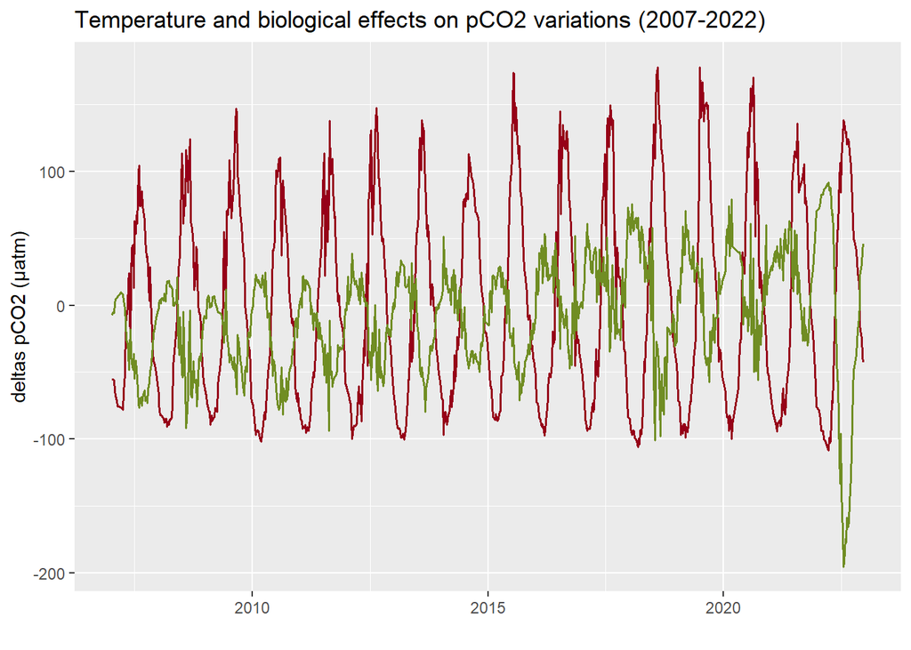

## Calculation of air-surface CO<sub>2</sub> flux

### Method 1 : Wanninkhof (2014)

Formula : 7.7 * 10–4 * U² * ΔpCO2

unity : mol of C / m² / year

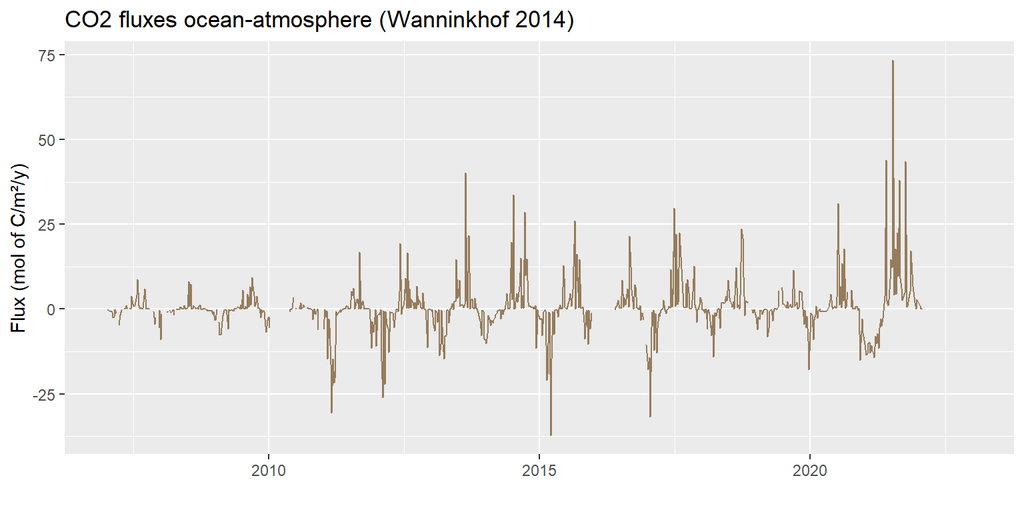

### Method 2 : Wanninkhof (1992)

Formulas :

- K600 = 0.266 * U²
- SC = 2073.1 - (125.62 * T) + (3.6276 * T²) - (0.043219 * T^3)
- k = K600 * (SC/600)^0.5
- K0 = Henry’s constant (seacarb)

Final formula : F = k * K0 * ΔpCO2

unity : mol of C / m² / year

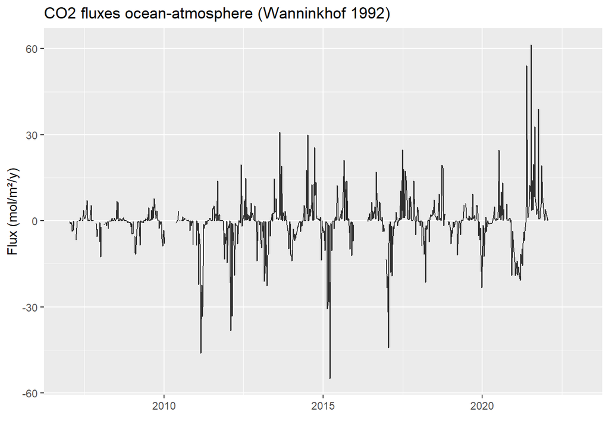

#### Table comparing the results of the 2 CO<sub>2</sub> flux calculation methods

```
##       Datetime   Flux_CO2_92 Flux_CO2_2014         Delta
## 1   2007-01-09  -0.453980428  -0.340018137 -1.139623e-01
## 2   2007-01-16  -0.487971204  -0.365357398 -1.226138e-01
## 3   2007-01-23  -0.952515233  -0.712065727 -2.404495e-01
## 4   2007-01-30  -0.571127362  -0.415558245 -1.555691e-01
## 5   2007-02-06  -1.264208258  -0.909326156 -3.548821e-01
## 6   2007-02-13  -3.551784770  -2.519286169 -1.032499e+00
## 7   2007-02-20  -3.324477902  -2.325185415 -9.992925e-01
## 8   2007-02-27  -0.149284372  -0.104357307 -4.492707e-02
## 9   2007-03-06  -1.702334749  -1.189399708 -5.129350e-01
## 10  2007-03-13            NA            NA            NA
## 11  2007-03-20            NA            NA            NA
## 12  2007-03-27  -6.814703024  -4.737711787 -2.076991e+00
## 13  2007-04-03  -2.420176799  -1.675933765 -7.442430e-01
## 14  2007-04-10  -0.344824979  -0.250519185 -9.430579e-02
```

[output cut: 836 more lines]